# Basic R Programming (v4.0)

```r
mtcars$car <- rownames(mtcars)
mtcars <- mtcars[, c(12, 1:11)]
head(mtcars)
```

```
##                                 car  mpg cyl disp  hp drat    wt  qsec vs am
## Mazda RX4                 Mazda RX4 21.0   6  160 110 3.90 2.620 16.46  0  1
## Mazda RX4 Wag         Mazda RX4 Wag 21.0   6  160 110 3.90 2.875 17.02  0  1
## Datsun 710               Datsun 710 22.8   4  108  93 3.85 2.320 18.61  1  1
## Hornet 4 Drive       Hornet 4 Drive 21.4   6  258 110 3.08 3.215 19.44  1  0
## Hornet Sportabout Hornet Sportabout 18.7   8  360 175 3.15 3.440 17.02  0  0
## Valiant                     Valiant 18.1   6  225 105 2.76 3.460 20.22  1  0
##                   gear carb
## Mazda RX4            4    4
## Mazda RX4 Wag        4    4
## Datsun 710           4    1
## Hornet 4 Drive       3    1
## Hornet Sportabout    3    2
## Valiant              3    1
```

```r
mtcarNew <- mtcars %>% gather(attribute, value, -car)
head(mtcarNew)
```

```
##                 car attribute value
## 1         Mazda RX4       mpg  21.0
## 2     Mazda RX4 Wag       mpg  21.0
## 3        Datsun 710       mpg  22.8
## 4    Hornet 4 Drive       mpg  21.4
## 5 Hornet Sportabout       mpg  18.7
## 6           Valiant       mpg  18.1
```

```r
tail(mtcarNew)
```

```
##                car attribute value
## 347  Porsche 914-2      carb     2
## 348   Lotus Europa      carb     2
## 349 Ford Pantera L      carb     4
## 350   Ferrari Dino      carb     6
## 351  Maserati Bora      carb     8
## 352     Volvo 142E      carb     2
```

```
* spread(data, key, value, fill = NA, convert = FALSE, drop = TRUE)
```

```r
mtcarSpread <- mtcarNew %>% spread(attribute, value)
head(mtcarSpread)
```

```
##                  car am carb cyl disp drat gear  hp  mpg  qsec vs    wt
## 1        AMC Javelin  0    2   8  304 3.15    3 150 15.2 17.30  0 3.435
## 2 Cadillac Fleetwood  0    4   8  472 2.93    3 205 10.4 17.98  0 5.250
## 3         Camaro Z28  0    4   8  350 3.73    3 245 13.3 15.41  0 3.840
## 4  Chrysler Imperial  0    4   8  440 3.23    3 230 14.7 17.42  0 5.345
## 5         Datsun 710  1    1   4  108 3.85    4  93 22.8 18.61  1 2.320
## 6   Dodge Challenger  0    2   8  318 2.76    3 150 15.5 16.87  0 3.520
```

```
* unite(data, col, ..., sep = "_", remove = TRUE)
```

```r
set.seed(1)
date <- as.Date('2016-01-01') + 0:14
hour <- sample(1:24, 15)
min <- sample(1:60, 15)
second <- sample(1:60, 15)
event <- sample(letters, 15)
data <- data.frame(date, hour, min, second, event)
data
```

```
##          date hour min second event
## 1  2016-01-01    4  15     35     w
## 2  2016-01-02    7  21      6     x
## 3  2016-01-03    1  37     10     f
## 4  2016-01-04    2  41     42     g
## 5  2016-01-05   11  25     38     s
## 6  2016-01-06   14  46     47     j
## 7  2016-01-07   18  58     20     y
## 8  2016-01-08   22  54     28     n
## 9  2016-01-09    5  34     54     b
## 10 2016-01-10   16  42     44     m
## 11 2016-01-11   10  56     23     r
## 12 2016-01-12    6  44     59     t
## 13 2016-01-13   19  60     40     v
## 14 2016-01-14   23  33     51     o
## 15 2016-01-15    9  20     25     a
```

```r
dataNew <- data %>%
  unite(datehour, date, hour, sep = ' ') %>%
  unite(datetime, datehour, min, second, sep = ':')
dataNew
```

```
##               datetime event
## 1   2016-01-01 4:15:35     w
## 2    2016-01-02 7:21:6     x
## 3   2016-01-03 1:37:10     f
## 4   2016-01-04 2:41:42     g
## 5  2016-01-05 11:25:38     s
## 6  2016-01-06 14:46:47     j
## 7  2016-01-07 18:58:20     y
## 8  2016-01-08 22:54:28     n
## 9   2016-01-09 5:34:54     b
## 10 2016-01-10 16:42:44     m
## 11 2016-01-11 10:56:23     r
## 12  2016-01-12 6:44:59     t
## 13 2016-01-13 19:60:40     v
## 14 2016-01-14 23:33:51     o
## 15  2016-01-15 9:20:25     a
```

```
* separate(data, col, into, sep = "[^[:alnum:]]+", remove = TRUE, convert = FALSE, extra = "warn", fill = "warn", ...)
```

```r
data1 <- dataNew %>%
  separate(datetime, c('date', 'time'), sep = ' ') %>%
  separate(time, c('hour', 'min', 'second'), sep = ':')
data1
```

```
##          date hour min second event
## 1  2016-01-01    4  15     35     w
## 2  2016-01-02    7  21      6     x
## 3  2016-01-03    1  37     10     f
## 4  2016-01-04    2  41     42     g
## 5  2016-01-05   11  25     38     s
## 6  2016-01-06   14  46     47     j
## 7  2016-01-07   18  58     20     y
## 8  2016-01-08   22  54     28     n
## 9  2016-01-09    5  34     54     b
## 10 2016-01-10   16  42     44     m
## 11 2016-01-11   10  56     23     r
## 12 2016-01-12    6  44     59     t
## 13 2016-01-13   19  60     40     v
## 14 2016-01-14   23  33     51     o
## 15 2016-01-15    9  20     25     a
```

- purrr

  > purrr enhances R’s functional programming (FP) toolkit by providing a complete and consistent set of tools for working with functions and vectors. If you’ve never heard of FP before, the best place to start is the family of map() functions which allow you to replace many for loops with code that is both more succinct and easier to read. The best place to learn about the `map()` functions is the iteration chapter in R for data science.

```r
library(purrr)
```

```r
mtcars %>%
  split(.$cyl) %>% # from base R
  map(~ lm(mpg ~ wt, data = .)) %>%
  map(summary) %>%
  map_dbl("r.squared")
```

```
##         4         6         8
## 0.5086326 0.4645102 0.4229655
```

- stringr

  > stringr is built on top of stringi, which uses the ICU C library to provide fast, correct implementations of common string manipulations. stringr focusses on the most important and commonly used string manipulation functions whereas stringi provides a comprehensive set covering almost anything you can imagine.

```r
library(stringr)

x <- c("why", "video", "cross", "extra", "deal", "authority")
str_length(x)
```

```
## [1] 3 5 5 5 4 9
```

```r
str_c(x, collapse = ", ")
```

```
## [1] "why, video, cross, extra, deal, authority"
```

```r
str_sub(x, 1, 2)
```

```
## [1] "wh" "vi" "cr" "ex" "de" "au"
```

```r
str_dup(x, 2:7)
```

```
## [1] "whywhy"
## [2] "videovideovideo"
## [3] "crosscrosscrosscross"
## [4] "extraextraextraextraextra"
## [5] "dealdealdealdealdealdeal"
## [6] "authorityauthorityauthorityauthorityauthorityauthorityauthority"
```

```r
str_subset(x, "[aeiou]")
```

```
## [1] "video"     "cross"     "extra"     "deal"      "authority"
```

```r
str_count(x, "[aeiou]")
```

```
## [1] 0 3 1 2 2 4
```

```r
str_detect(x, "[aeiou]")
```

```
## [1] FALSE  TRUE  TRUE  TRUE  TRUE  TRUE
```

```r
str_subset(x, "[aeiou]")
```

```
## [1] "video"     "cross"     "extra"     "deal"      "authority"
```

```r
str_locate(x, "[aeiou]")
```

```
##      start end
## [1,]    NA  NA
## [2,]     2   2
## [3,]     3   3
## [4,]     1   1
## [5,]     2   2
## [6,]     1   1
```

```r
str_extract(x, "[aeiou]")
```

```
## [1] NA  "i" "o" "e" "e" "a"
```

```r
str_match(x, "(.)[aeiou](.)")
```

```
##      [,1]  [,2] [,3]
## [1,] NA    NA   NA
## [2,] "vid" "v"  "d"
## [3,] "ros" "r"  "s"
## [4,] NA    NA   NA
## [5,] "dea" "d"  "a"
## [6,] "aut" "a"  "t"
```

```r
str_replace(x, "[aeiou]", "?")
```

```
## [1] "why"       "v?deo"     "cr?ss"     "?xtra"     "d?al"      "?uthority"
```

```r
str_split(c("a,b", "c,d,e"), ",")
```

```
## [[1]]
## [1] "a" "b"
##
## [[2]]
## [1] "c" "d" "e"
```

## What’s new in R 4.1.0?

#### 1. New **pipe operator**: `|>`

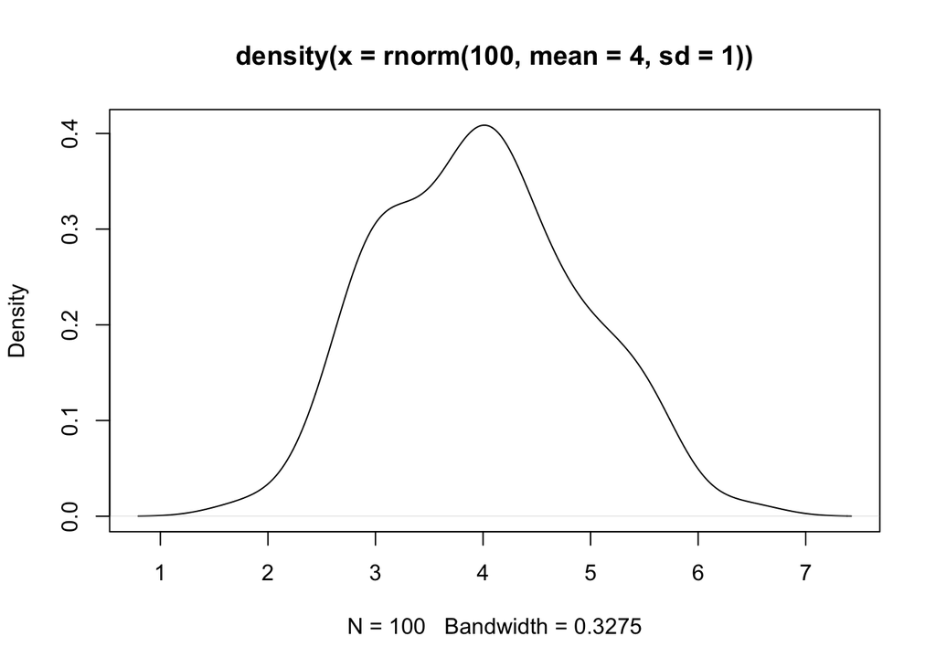

```r
rnorm(100, mean = 4, sd = 1) |>
  density() |>
  plot()
```

```r
c("Homo sapiens", "Mus musculus", "Rattus norvegicus") |> {function(i) grepl("homo", i, ignore.case = TRUE)}()
```

```
## [1]  TRUE FALSE FALSE
```

#### 2. Simplified function statement with `\`

- How did we write a self-defined function in `map()` function before R 4.1.0?

```r
map(
  letters[2:3],
  function(x) {
    pattern <- paste0("^", x)
    grep(pattern, ls("package:datasets"), value = TRUE, ignore.case = TRUE)
  }
)
```

- Since R 4.1.0, we can write it again in this style:

```r
map(
  letters[2:3],
  \(x){
    pattern <- paste0("^", x)
    grep(pattern, ls("package:datasets"), value = TRUE, ignore.case = TRUE)
  }
)
```

```
## [[1]]
## [1] "beaver1"      "beaver2"      "BJsales"      "BJsales.lead" "BOD"
##
## [[2]]
## [1] "cars"        "ChickWeight" "chickwts"    "co2"         "CO2"
## [6] "crimtab"
```

## Updates in R 4.2.0

- Use **pipe operator** more elegantly with the underscore placeholder **_**
  - In R 4.1

```r
mtcars |> (\(x) lm(hp ~ cyl, data = x))()
```

- In R 4.2

```r
mtcars |> lm(hp ~ cyl, data = _)
```

## Drawing graph

#### [ggplot2](http://ggplot2.org/)

> ggplot2 is a plotting system for R, based on the grammar of graphics, which tries to take the good parts of base and lattice graphics and none of the bad parts. It takes care of many of the fiddly details that make plotting a hassle (like drawing legends) as well as providing a powerful model of graphics that makes it easy to produce complex multi-layered graphics.

##### The Grammar of Graphics Philosophy

ggplot2 follows the “Grammar of Graphics” approach, where plots are built layer by layer using these key components:

1. **Data**: The dataset you want to visualize
2. **Aesthetics (aes)**: How variables map to visual properties (x, y, color, size, etc.)
3. **Geometries (geom)**: The visual elements (points, lines, bars, etc.)
4. **Statistics (stat)**: Statistical transformations of data
5. **Coordinates (coord)**: The coordinate system
6. **Facets**: Split data into subplots
7. **Themes**: Overall visual appearance

##### Basic ggplot2 Syntax

The basic structure of a ggplot2 command:

```r
# Install ggplot2 if not already installed
install.packages("ggplot2")
library(ggplot2)

# Basic syntax
ggplot(data = <DATA>) +
  <GEOM_FUNCTION>(mapping = aes(<MAPPINGS>))
```

##### Getting Started with Simple Examples

Let’s use the built-in `mtcars` dataset to learn ggplot2:

```r
# First, let's explore our data
library(ggplot2)
head(mtcars)
```

```
##                                 car  mpg cyl disp  hp drat    wt  qsec vs am
## Mazda RX4                 Mazda RX4 21.0   6  160 110 3.90 2.620 16.46  0  1
## Mazda RX4 Wag         Mazda RX4 Wag 21.0   6  160 110 3.90 2.875 17.02  0  1
## Datsun 710               Datsun 710 22.8   4  108  93 3.85 2.320 18.61  1  1
## Hornet 4 Drive       Hornet 4 Drive 21.4   6  258 110 3.08 3.215 19.44  1  0
## Hornet Sportabout Hornet Sportabout 18.7   8  360 175 3.15 3.440 17.02  0  0
## Valiant                     Valiant 18.1   6  225 105 2.76 3.460 20.22  1  0
##                   gear carb
## Mazda RX4            4    4
## Mazda RX4 Wag        4    4
## Datsun 710           4    1
## Hornet 4 Drive       3    1
## Hornet Sportabout    3    2
## Valiant              3    1
```